# Module 2 Lecture - Descriptive Statistics and Plots

Introduction to Statistical Methods

Quinton Quagliano, M.S., C.S.P

Department of Educational Psychology

# 1 Overview and Introduction

Agenda

1 Overview and Introduction

2 Descriptive Statistics

3 Descriptive Plots

4 Conclusion

## 1.1 Objectives

- Display data graphically and interpret graphs
- Recognize, describe, and calculate the measures of location of data (quantiles and percentiles)
- Recognize, describe, and calculate the measures of center tendency
- Recognize, describe, and calculate the measures of dispersion
- Understand the complementary value of visual and numeric descriptions of data
- Be able to compare and contrast the use cases for different metrics

## 1.2 Introduction

- Data, in it’s raw form, is very confusing
  - Especially large data sets are likely to be borderline un-interpretable
- **Discuss: With the following table, try to say something meaningful about this data/explain it**

| Student | Q1 | Q2 | Q3 | Q4 | Q5 |
| --- | --- | --- | --- | --- | --- |
| Student 1 | 1 | 0 | 1 | 1 | 0 |
| Student 2 | 0 | 1 | 0 | 1 | 1 |
| Student 3 | 1 | 1 | 1 | 0 | 0 |
| Student 4 | 0 | 0 | 1 | 0 | 1 |
| Student 5 | 1 | 1 | 0 | 1 | 1 |

- Realistically, we need a way to describe our datasets in a way that capture the overarching trends in the values
  - This can be done both graphically and via descriptive statistics, and often times, both!
  - Though this is a statistics class, sometimes the graphs are the most understandable part of a research paper!
- **Important: There is usually not only one 'right' way to graph or represent data - it may be advantageous to try multiple methods and see how they compare**
- The book is filled with examples and practices to get better at navigating these, please try some of them!

# 2 Descriptive Statistics

Agenda

1 Overview and Introduction

2 Descriptive Statistics

3 Descriptive Plots

4 Conclusion

## 2.1 Percentiles and Quartiles

- **Quartiles** are used to cut numerical data into 4 equal-sized chunks when the data is ordered smallest to largest
  - $Q_1$ (first quartile) is above 1/4 or 25% of the data
  - $Q_2$ (second quartile) is above 1/2 or 50% of the data, or the median
  - $Q_3$ (third quartile) is above 3/4 or 75% of the data
  - For example, if I state $Q_3 = 20$, that means that the value of 20 is above 75% of the data
  - Used in Box plots, we’ll get to that in a bit
- **Discuss: If quartiles split the data into 4 equal sections, how many sections are in quantiles**
- **Percentiles** function the same as quartiles, but divide the data into 100 equal-sized sections
  - For example, the at the 90th percentile, 90% of scores are lower
  - Percentiles are especially commonly used to describe roughly where individual data points fall - this comes up often in standardized testing
  - The 25th percentile is equivalent to $Q_1$, 50th percentile is equivalent to $Q_2$ (and thus, the median), and the 75th percentile is equivalent to $Q_3$
  - For example, if I state that the 23rd percentile is $45$, then the value of 45 is above 23% of the data

### A Formula for Finding the Kth Percentile

- Often times, we want to know what value corresponds to a certain percentile in a dataset
  - We can use the following formula to calculate this

$$i = \frac{k}{100}*(n + 1)$$

- Where:
  - $i$ is the index or rank of the value when ordered smallest to largest
  - $k$ is the $k^{th}$ percentile
  - $n$ is the total number of data points
- If $i$ ends up being between two integers, i.e., a decimal, then we round up and down to the nearest ranks and take the average of their integers
  - It’s worth mentioning this is just one of many procedures for finding the $k^{th}$ percentile…
- For a formula like this, it is easiest to approach it algebraically, just inserting the chosen values over the letters in the formula
- **Discuss: Try writing out this same equation, replacing k with 20 and n with 12 - could you solve it from here?**

### Example of Finding Kth Percentile

**Dataset:** 5, 6, 7, 8, 9 (ordered smallest to largest)

**Prompt:** What value corresponds to the 70th percentile?

$$i = \frac{70}{100}*(5 + 1)$$

$$i = 0.70*6$$

$$i = 4.2$$

We round $i$ up and down to the 4th and 5th ranks, which correspond to values 8 and 9 in the dataset, their average is 8.5 $\rightarrow$ 70th percentile

- **Question: If I wanted to find what value corresponds to $Q_2$ what $k$ would I use in this formula?**
- A) 10
- B) 20
- C) 25
- D) 50

### A Formula for Finding the Percentile of a Value in a Data Set

- We can go the opposite direction to figure out what a specific datapoint’s percentile is

$$\frac{x+0.5y}{n}*100$$

- Where:
  - $x$ is the number of data points up to and NOT including the point of interest
  - $y$ the number of occurrences of the values of interest
  - $n$ is the total number of data points
- Like the prior formula, this is just *one* procedure, you may run into others in the wild

### Example of Finding Percentile of a Value in a Data Set

**Dataset:** 5, 6, 7, 8, 9 (ordered smallest to largest)

**Prompt:** What percentile is value ‘8’ at?

$$\frac{3+0.5(1)}{5}*100$$

$$\frac{3.5}{5}*100$$

$$70 \rightarrow percentile$$

- **WAIT!** Didn’t we just say that 8.5 is the 70th percentile in the last example?
  - Yes, that is because these formulas are only approximations, and work poorly in small datasets
  - There are several slight variations on calculating these, but the formulas above is what we will use for this class

## 2.2 Descriptive Tables and Frequencies

- **Simple frequency** is a count of the number of cases – or frequency - that fall in the different categories or that obtain certain scores.
  - E.g., - the number of girls and boys in a sample the number of students who identify themselves as African-American, Asian- American, Hispanic, or White on a questionnaire; the number of people who obtain different scores on a test
- **Relative frequency** is the proportion or percentage of cases for each score in the distribution
- **Cumulative frequency** is a count of the number of cases that fall below a certain score. A cumulative frequency is provided for all scores in the distribution
- **Cumulative relative frequency** is the proportion or percentage of cases that fall below a certain score.

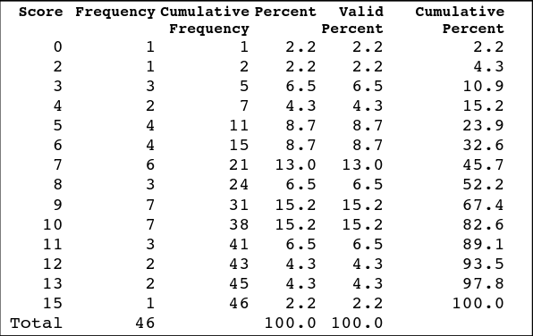

- **Discuss: Based on your reading of the above table, what is the cumulative frequency at score '11'?**

## 2.3 Measures of Central Tendency

- **Measures of central tendency** of a distribution are statistics that summarize scores that are typical, central or average in the distribution.
  - The most common measures of central tendency in the social sciences are the mode, the median, and the mean.
- The **mode** is the most commonly occurring value in a variable/dataset
  - Mode is often just spelled out, and not given a special notation
  - There is not a very useful formula for finding the mode, but realistically all you need to do use Bar Graphs and find the tallest bar (for the highest frequency)
- Example of finding mode of a sample dataset:
  - I have 5 students with the following sexes: $\{F, M, F, F, M\}$
  - I have 3 female students, and 2 male students, thus the **sample mode of the sex variable is ‘Female’**, as that is the most common value in that variable
- The **median** is the value at the 50th percentile, second quartile ($Q_2$), or, put simply, the value that divides the data into two equal halves when ordered from smallest to largest
  - In the case that there is no actual exact middle value when ordered smallest to largest, we’d average the two middle-most values
  - Sample median statistic notation: $X_m$
  - Population median parameter notation: $M$
  - The best strategy for finding median is to order the values and then cross values off from both ends until you end up with one uncrossed value
  - To find the *location* of the median, one can do: $\frac{n + 1}{2}$, where:
    - $n$: number of observations/people
- Example of finding median of a sample dataset:
  - I have the following test scores: $\{23, 61, 35, 89, 74\}$
  - First, we have to order the data smallest to largest: $\{23, 35, 61, 74, 89\}$
  - If I cross off each side of the data: $\{\cancel{23, 35}, 61, \cancel{74, 89}\}$
  - Thus, my **sample median of test scores is 61** or $X_{M,TestScore} = 61$
  - Using the location formula: $\frac{5 + 1}{2} = 3 \rightarrow$ the 3rd number in the order is the median
- The **mean** is the arithmetic average of the data
  - Sample mean statistic notation: $\bar{x}$ (x-bar)
  - Population mean parameter notation: $\mu$ (mu)
  - The sample mean is calculated with:

$$\bar{x} = \frac{x_1 + x_2 + x_3 + .... + x_n}{n}$$

- Example of finding mean of a sample dataset
  - I have the following GPAs: $\{1.00, 1.00, 2.50, 3.00, 4.00\}$
  - Using the formula: $\frac{1 + 1 + 2.50 + 3.00 + 4.00}{n} = \frac{11.50}{5} = 2.3$
  - Thus, **my sample mean of GPAs is 2.3** or $\bar{x}_{GPA} = 2.3$
- **Important: Something worth noting is that the median is less prone to be affected by outliers than the mean, making it useful in certain circumstances.**
- **Question: I have data 1,2,2,2,3,4,5. Datapoint 2 is the most commonly occurring value, thus it is the [BLANK]**
- A) Mode
- B) Median
- C) Mean
- D) None of the above
- **Discuss: Find the mean, median, and mode of the following data: 1, 1, 2, 3, 5, 6, 8, 9, 10**

## 2.4 The Law of Large Numbers and the Mean

- As a general rule, as the sample size ($n$) grows, $\bar{x}$ and $\mu$ converge - this is true of most statistic - parameter relationships
  - This is related to the central limit theorem, to be discussed slightly later
  - However, this also explains why bigger samples are often treated as better in a lot of scientific research - because the sample statistics better approximate the parameters
- **Discuss: Review: Try explaining, from Module 1, why a more representative statistic is a good thing for our research?**

## 2.5 Measures of Dispersion

- **Measures of dispersion** are statistics that summarize how data is spread out across a distribution
  - The most common measures of dispersion we should be concerned with are standard deviation, variance, range, and interquartile range.
- Each number in a dataset has a **deviation**, or how far away it is from the mean
  - This is calculated simply as the difference between the value and the sample mean of the data
  - $x - \bar{x}$ or
  - $x_i - \bar{x}$
- Example of calculating deviation of a single point:
  - We have dataset with $\bar{x} = 5$, and we are interested in the individual point of $10$
  - Using the deviation formula: $10 - 5 = 5$, thus the deviation of point 10 is 5
- To calculate the standard deviation, we first will calculate the **variance**, which is just the squared standard deviation
  - Sample variance statistic: $s^2$
  - Population variance parameter: $\sigma^2$
  - The variance sample statistic and population parameter formulas are, respectively:

$$s^2 = \frac{\sum{(x-\bar{x})^2}}{n-1}$$

$$\sigma^2 = \frac{\sum{(x-\mu)^2}}{n}$$

- **Important: The reason we must use variance to calculate standard deviation relates to the need to square in order to avoid getting 0 from summing the deviations**
- By far, the most important and most used way to describe the spread of all the data is the **standard deviation**
  - A measure of the average distance away from the mean that a point is in a distribution
  - It is used instead of variance because it removes the “square” from interpretation
  - Sample standard deviation statistic: $s$
  - Population standard deviation parameter: $\sigma$ (sigma)
  - The standard deviation sample statistic and population parameter formulas are, respectively:

$$s = \sqrt{\frac{\sum{(x-\bar{x})^2}}{n-1}}$$

$$\sigma = \sqrt{\frac{\sum{(x-\mu)^2}}{n}}$$

- **Important: Realistically, we tend to only directly use the sample statistics calculations**
- **Discuss: Look back at the previous equations; which of the measures of central tendency sees the greatest use in these formulas?**
- The **range** is the difference between the largest and smallest values in the data
- Example of calculating range in a sample:
  - Data: $\{4, 2, 6, 8, 20\}$
  - Subtracting smallest and largest values: $20 - 2 = 18$, **18 is the range of the sample**
- The **interquartile range (IQR)** is the 75th percentile (upper quartile, $Q_3$) minus the 25th percentile (lower quartile, $Q_1$). It is the width of the interval that contains the middle 50% of the data.
  - In formula it could be represented as: $Q_3 - Q_1 = IQR$

## 2.6 Calculating Measures of Dispersion

### Calculating Variance and Standard Deviation

While not necessary with computers and calculators, it can be useful to work out statistics “by hand” for learning how they work. For example:

**Dataset:** 1, 2, 3, 4, 5

**Size of sample:** $n = 5$

**Sample Mean:**

$$\bar{x} = \frac{x_1 + x_2 + x_3 + .... + x_n}{n}$$

$$3 = \frac{1 + 2 + 3 + 4 + 5}{5}$$

**Sample Variance:**

$$s^2 = \frac{\sum{(x-\bar{x})^2}}{n-1}$$

Hint: whenever you see a $\sum$ sign, follow this tabular procedure

| x | x - xbar | (x-xbar)^2 |
| --- | --- | --- |
| 1 | 1 - 3 | -2^2 |
| 2 | 2 - 3 | -1^2 |
| 3 | 3 - 3 | 0^2 |
| 4 | 4 - 3 | 1^2 |
| 5 | 5 - 3 | 2^2 |
|  | Sum | 10 |

$$2.5 = \frac{10}{5-1}$$

**Sample Standard Deviation:**

$$s = \sqrt{s^2}$$

$$1.58 = \sqrt{2.5}$$

### Describing Points and Values with Standard Deviations (Z-scores)

- Much like describing a specific value with a percentile, we may want to describe how far away from the mean a certain point is, and we can do so using the standard deviation
- We can do this with what are called **z-score** with the following formula for sample:

$$z = \frac{x - \bar{x}}{s}$$

- Where: $x$ is a individual data value of interest $s$ is the standard deviation

**By hand (pulling from last example):**

$$-0.63 = \frac{2 - 3}{1.58}$$

- We could then say that the value of 2 is -0.63 standard deviations away from the mean of 3
- **Discuss: Try working out the z-score of 5 given that same dataset**
- Z-scores are often used in conjunction with Percentiles and Quartiles, to describe a position of an individual in a broader dataset

## 2.7 Aside on Outliers

- An **outlier**, also known as an **extreme value**, is a data point that falls far from the others, somehow breaking from the pattern of the data
  - While more commonly applied to numeric data, it could sometimes be used to describe a single member of a qualitative label
  - It is characteristic for this point to have an extreme z-score, i.e., be many standard deviations away from the mean
- **Important: 'Outlier' can be a frustratingly loose term in statistics, because there is not one always accepted answer for just how far a point needs to be removed to be an outlier. Make sure to read carefully to see how any one given author defines it in an individual example or study.**
- Many graphical methods naturally detect outliers in the data
  - In plots, you are mainly just looking for visual anomalies, or breaks in the visual pattern

## 2.8 Descriptions of Distributions

- There are several characteristics that are not well described as either Measures of Dispersion or Measures of Central Tendency, but still helpful in understanding the layout of a continuous distribution
- Usually, we use The Normal Distribution as an “ideal”, and describe variables’ distribution in how it relates to the normal distribution
  - This is how we will describe Skewness, Kurtosis, and Modality
- There are several different ways to describe these characteristics with numeric statistics, but for now, we’ll just focus on how they appear graphically in a histogram

### Skewness

- **Skewness** is a description of how a distribution departs from symmetry or has a ‘tail’
  - A **positive/right skew**: when a distribution has most values clustered towards the low end, and a tail out to the right side of the frequency histogram
  - A **negative/left skew**: when a distribution has most values clustered towards the high end, and a tail out to the left side of the frequency histogram
- **Important: As a helpful mnemonic, the direction of the skew is the direction of the 'tail', not the 'hump'**

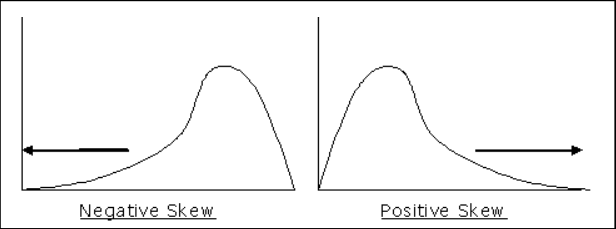

### Kurtosis

- **Kurtosis** is a description of how ‘peaked’ a distribution is
  - A **leptokurtic** distribution has too many scores concentrated in the center and not enough in the tails. (peaked)
  - A **platykurtic** distribution has too few scores in the center and too many in the tails. (flat)
  - The Normal Distribution is said to be mesokurtic

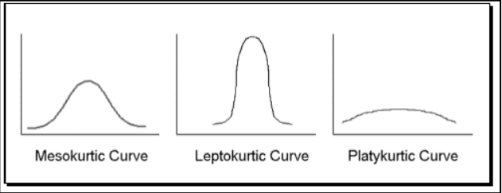

### Modality

- **Modality** a description of how many peaks a distribution has
  - A distribution is **unimodal** when is has only one peak, and **bimodal** when it has two peaks

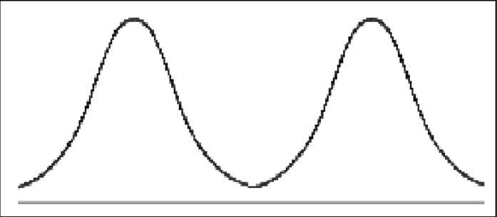

- **Discuss: Take a guess at what a distribution with three peaks would be called**

### The Normal Distribution

- **Important: The normal distribution, is an 'ideal' and used theoretically. In practice, collected raw data will never be perfectly normal. There are also other ideal distributions such as the exponential and uniform distributions, that are also useful in certain circumstances.**

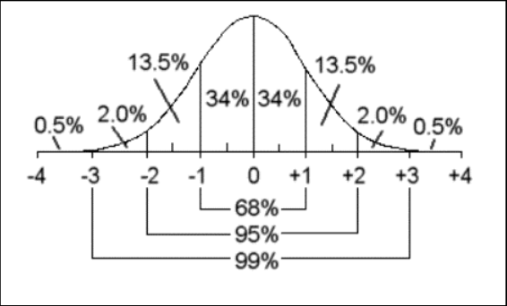

- The **normal distribution** is a distribution of a continuous variable that is unimodal, symmetrical, mesokurtic, bell-shaped, and the mean, median, and mode are equal
  - Follows the **empirical rule**
  - We’ll revisit this in it’s own module later on
- **Discuss: Reading the distribution chart above, at what number of standard deviations are 84 percent of values beneath it?**

## 2.9 Sampling Variability of Statistics

- As mentioned prior, different samples from the same population of interest will not be exactly the same, described as **sampling variation**
  - Thus, their data, means, standard deviations will all be somewhat different every time we take a new sample
  - If we were to take many representative samples, we would see slight variation across all of them
  - Put together, they are all just different estimates of their parameters (but the parameter is what we are after!)
  - Review:
    - $\bar{x}$ estimates $\mu$
    - $X_M$ estimates $M$
    - $s$ estimates $\sigma$

# 3 Descriptive Plots

Agenda

1 Overview and Introduction

2 Descriptive Statistics

3 Descriptive Plots

4 Conclusion

## 3.1 Introduction

- In this first section, we looked at primarily statistics and numeric representations, now we’ll look at some graphs used often to show frequencies of certain values in the data
- **Question: Review: Which of the following is NOT quantitative data?**
- A) Hair color
- B) Age (in years)
- C) Height (in cms)
- D) Total test score (in number of points)

## 3.2 Stem-and-Leaf Plots

- **Stem-and-leaf graphs**, also known as **stemplots**, are technically a tabular method to represent data - but function to visually inspect the distribution of the data.
- Stemplots a valid choice for representing numeric, quantitative data for a single variable
  - However it works best if the range of values is reasonably restricted, and with the same decimal structure
  - Continuous data may work, but discrete data can be somewhat easier
  - E.g., Test scores ranging from 0 - 100 $\rightarrow$ good!
  - E.g., Reaction time ranging from 0.50 secs - 420 seconds $\rightarrow$ bad!
- Stemplots contain a **leaf** which contains the **final significant digit** (in practice this is usually just the last digit)
  - Then, the stem is everything *but*, the digits of the leaf
  - Each number entry in a leaf represents a different value in the data
  - So technically, the number of digits that are leaves in the number of points in the data
- Practically, stemplots are useful showing distribution, skew, and frequency of values
  - Especially common in psychometrics
  - However, I do find they are harder to interpret for non-statistical audiences
- Example of test scores 0 - 100: 2, 3, 5, 6, 9, 11, 14, 15, 16, 20, 21, 23, 27, 30, 32, 38, 41, 44, 46, 53, 55, 59, 60, 62, 67, 74, 79, 81, 85, 90

| Stem | Leaf |
| --- | --- |
| 0 | 2 3 5 6 9 |
| 1 | 1 4 5 6 |
| 2 | 0 1 3 7 |
| 3 | 0 2 8 |
| 4 | 1 4 6 |
| 5 | 3 5 9 |
| 6 | 0 2 7 |
| 7 | 4 9 |
| 8 | 1 5 |
| 9 | 0 |

- **Discuss: Try to explain why a stem-and-leaf-plot would NOT work for qualitative, nominal data**
- As you’ll see in the following line and bar graphs, one difference is that stemplots don’t actually aggregate or summaries the data at all
  - One nice thing about these plots is that they actually leave the numbers somewhat intact, so you can see the entire dataset at a glance

## 3.3 Line Graphs

- **Line graphs** are a broad family of plots that always have some dotted data points connected by a continuous line
  - For our purpose, they are another way to visualize frequency of data points
- Unlike stemplots, they could technically be used for qualitative data (but I wouldn’t recommend that use)
  - Otherwise, the same rules for application apply from the stemplots
- In the line plot:
  - The height, or **y-axis**, represents the frequency of a certain value
  - The place on the **x-axis** represents what value’s frequency is represented by the y-axis

[figure not shown]

Figure 1: Frequency of Quiz Grades (0-10)

- **Discuss: Consider the above plot, do you feel there is anything confusing about interpreting it?**

## 3.4 Bar Graphs

- **Bar graphs** help show frequencies of values of categorical/nominal variables

[figure not shown]

Figure 2: Frequency of Students by Class

[figure not shown]

Figure 3: Frequency of Students by Class and Sex

- **Discuss: Come up with 2 additional examples of variable that could be well-represented with a bar chart**

## 3.5 Frequency Histograms

- A **frequency histogram**, at first glance, looks much like a bar plot, as described prior.
- However, rather than use individual discrete points or labels, histograms will group values by a defined **bin width**, and count the frequencies of values within that bin
  - All the intervals will be the same width, and we choose that width somewhat arbitrarily
  - But, its worth noting that the bin interval can have a major impact on the overarching interpretation
- **Important: Smaller bin size is not always better! Especially in data that is more spread out.**

[figure not shown]

Figure 4: Example of a Histogram (Bin width = 2)

## 3.6 Frequency Polygons

- **Important: Frequency polygons look remarkably similar to line graphs, but start from a different perspective on understanding frequency.**
- **Frequency polygons** can be though of as a line plot that that travels through the midpoint of histogram bars
  - So frequency polygons still use those same bin widths as with histograms, but don’t show that on the graph itself (unless overlaid)
  - This makes them more appropriate for dealing with continuous data

[figure not shown]

Figure 5: Frequency polygon

## 3.7 Box Plots

- **Boxplots** are useful for representing information about the quartiles, percentiles, and median all in a single plot
  - Also called **box-and-whisker** plots (may be the preferred name for the cat-lovers like myself)
- The centerline of a box plot represents a median, edges of the box represent $Q_1$ and $Q_3$ (i.e., the box is the IQR), the whiskers *usually* extend to the farthest values

[figure not shown]

Figure 6: Boxplot example

## 3.8 Practicing Choosing Descriptives and Plots

- Not all plots and descriptive statistics provide the same information - try the following questions for practice
- **Question: I want to graphically examine the median and IQR of SAT scores in a local school district, how could I do this?**
- A) Boxplot
- B) Frequency histogram
- C) Kurtosis
- D) Arithmetic Mean
- **Question: I want to know the numeric value most commonly appearing in a dataset, how could I find this?**
- A) Mean
- B) Median
- C) Boxplot
- D) Mode
- **Question: I want visually compare my variable of student wellbeing ratings (continuous) against a normal distribution, how could I best examine this?**
- A) Boxplot
- B) Bar plot
- C) Histogram
- D) Mean

## 3.9 Aside about Lying in Statistics

- With all of these different methods (any many more!) for visually representing data, we run into an issue: accidental or purposeful misleading with graphs
  - *“There are three kinds of lies: lies, damned lies, and statistics”* - Mark Twain (kind of, its complicated who exactly came up with this)
  - While often times taken out of context, this statement does ring true sometimes - we owe it to our readers to be careful
- **Important: One of the best ways to ensure that data is represented fairly is to try to represent it via multiple different methods - these different methods will help us see slightly different dimensions and information about the distribution.**
- Aim for *consistency and clarity in graphing*, avoiding uneven axis points, confusingly similar colors, and making sure enough information is included to understand the scale of the plot.
  - Easy tip: see if you can show the plot to someone not knowledgeable in the work and see if it makes sense to them

# 4 Conclusion

Agenda

1 Overview and Introduction

2 Descriptive Statistics

3 Descriptive Plots

4 Conclusion

## 4.1 Recap

- Understanding our data first starts with describing it, and we can accomplish that both through informative statistics and graph
- Measures of central tendency and dispersion can succinctly describe the center of data, and how spread out it is, respectively. They can be a useful way to quickly describe data in numbers.
- The various graphs show slightly different information, and multiple options may be used simultaneously to more thoroughly show the characteristics of the data
- The statistics we calculate on our sample are meant to accurately estimate the parameters of the population distribution, but that only works if our sample is representative and our data unbiased!
- Outliers and discussion on skew/kurtosis will return later when we are talking about their impact on inferential statistics, but don’t worry too much about that yet!

## 4.2 Lecture Check-in

- Make sure to complete any lecture check-in tasks associated with this lecture!

[figure not shown]

Module 2 Lecture - Descriptive Statistics and Plots || Introduction to Statistical Methods